# Gold Standard - Normalization Assessment

### item3

$item3

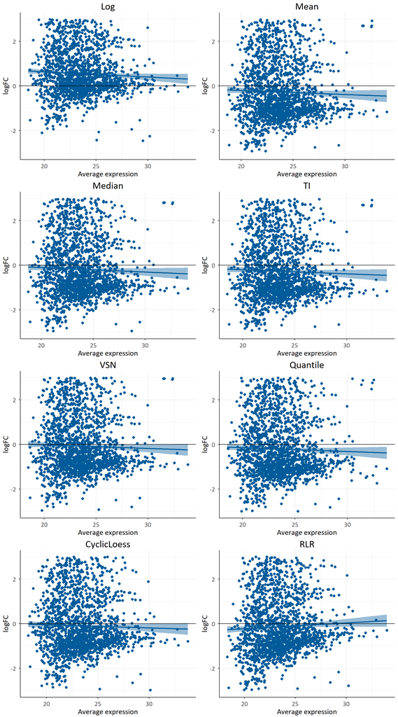

### item4

$item4

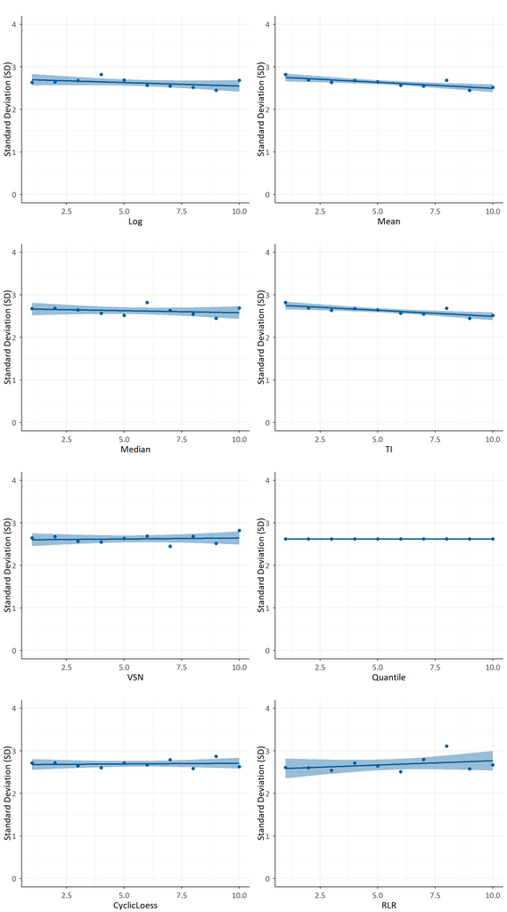

### item5

$item5

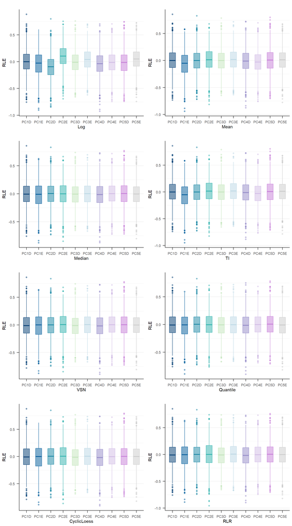

### item6

$item6

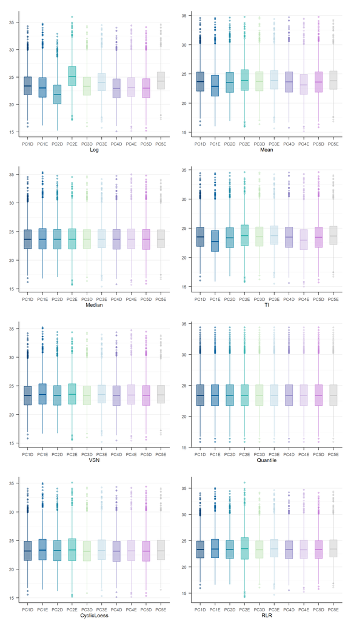

## PXD058699

### item0

$item0

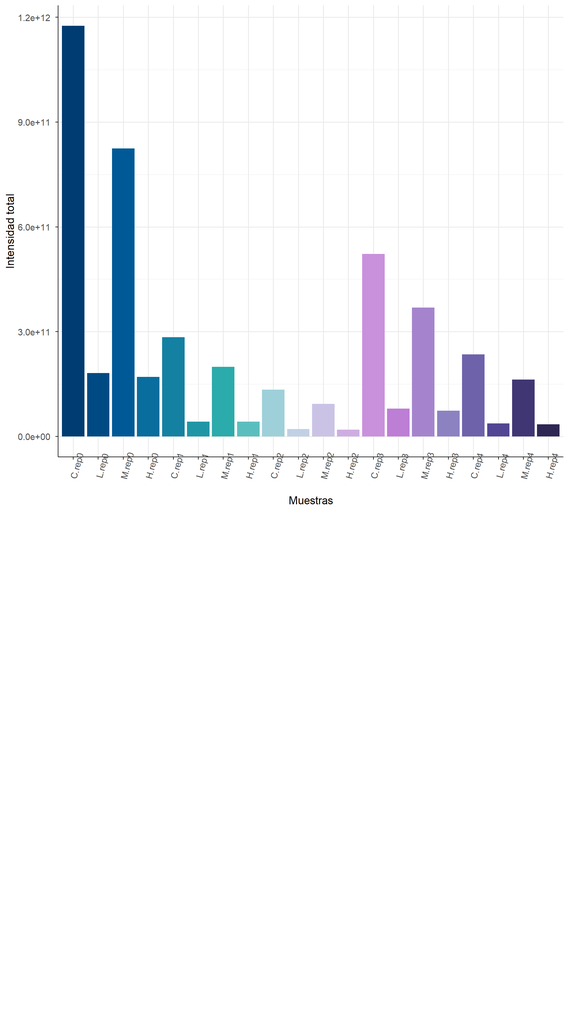

### item1

$item1

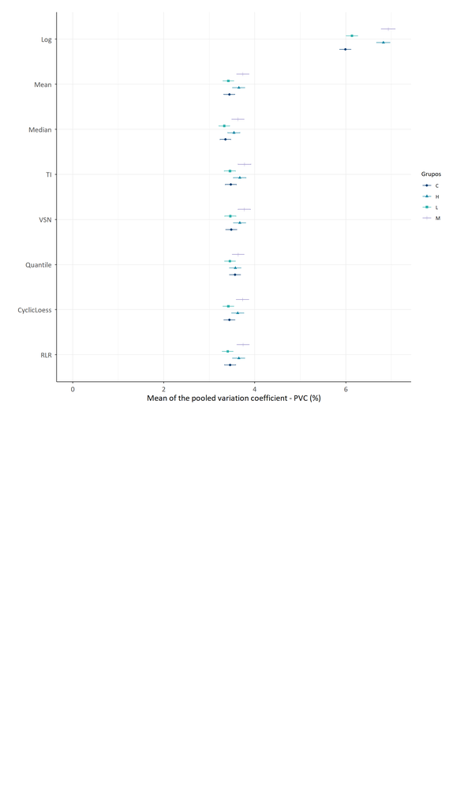

### item2

$item2

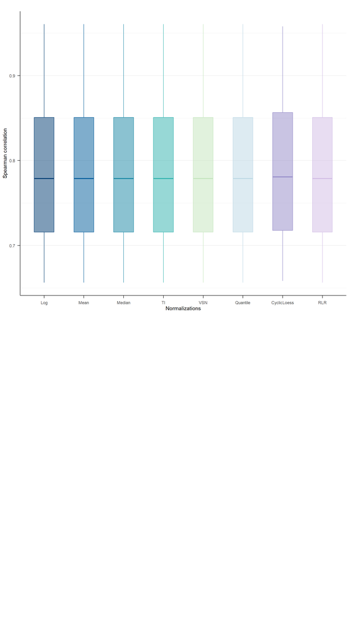

### item3

$item3

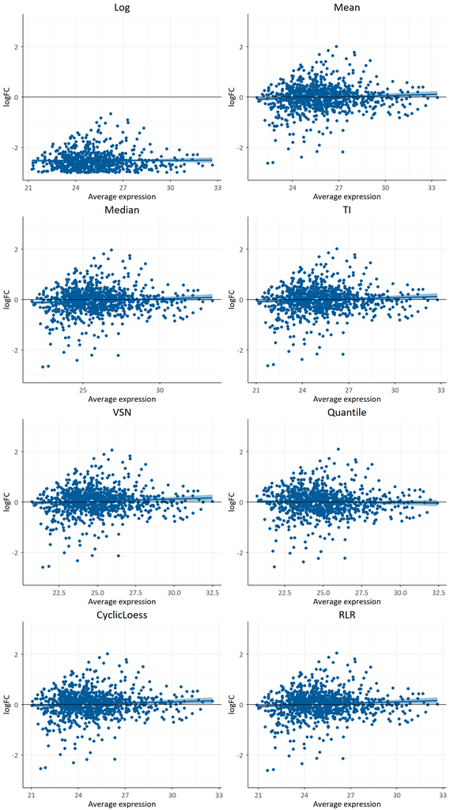

### item4

$item4

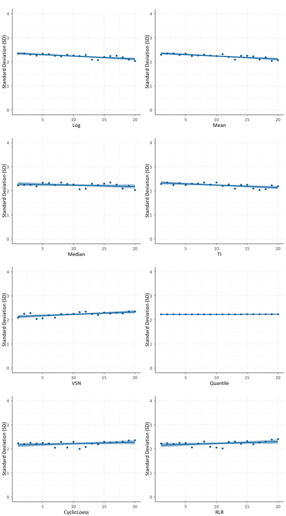

### item5

$item5

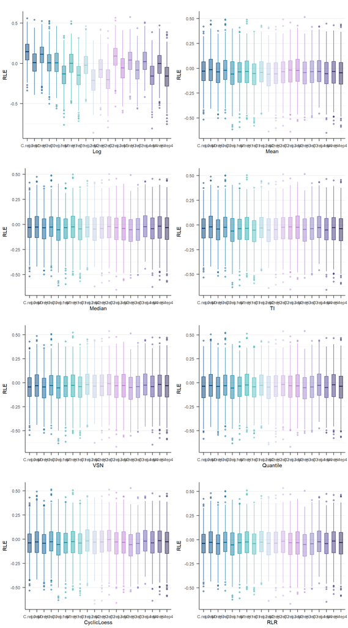

### item6

$item6

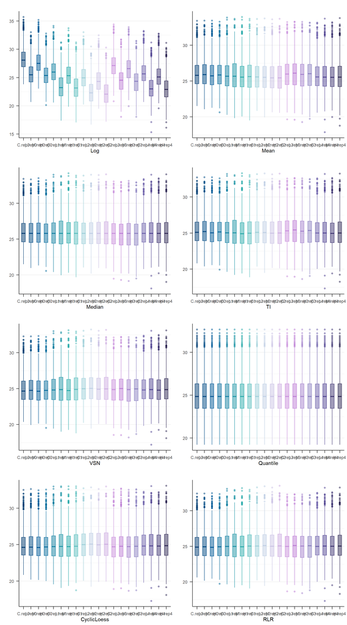

## PXD062018

### item0

$item0

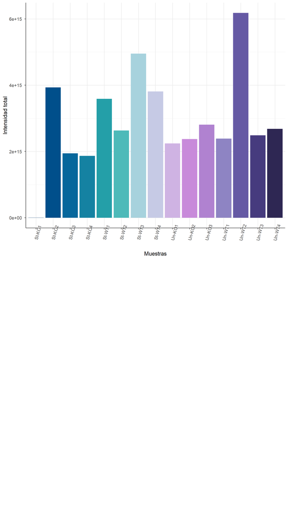

### item1

$item1

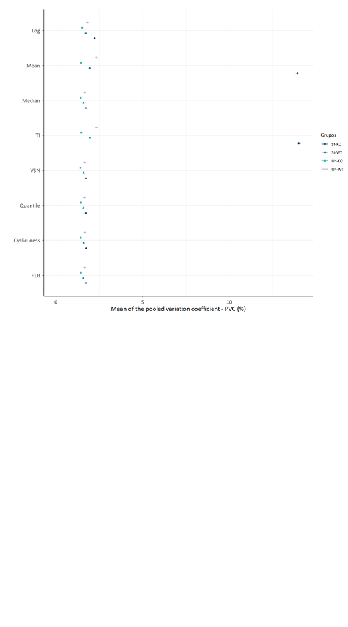

### item2

$item2

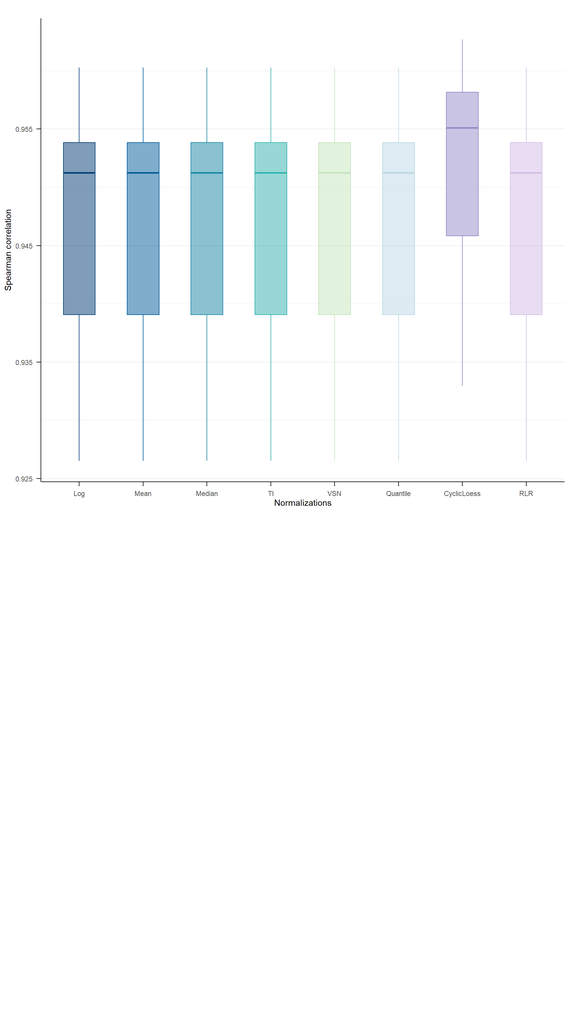

### item3

$item3

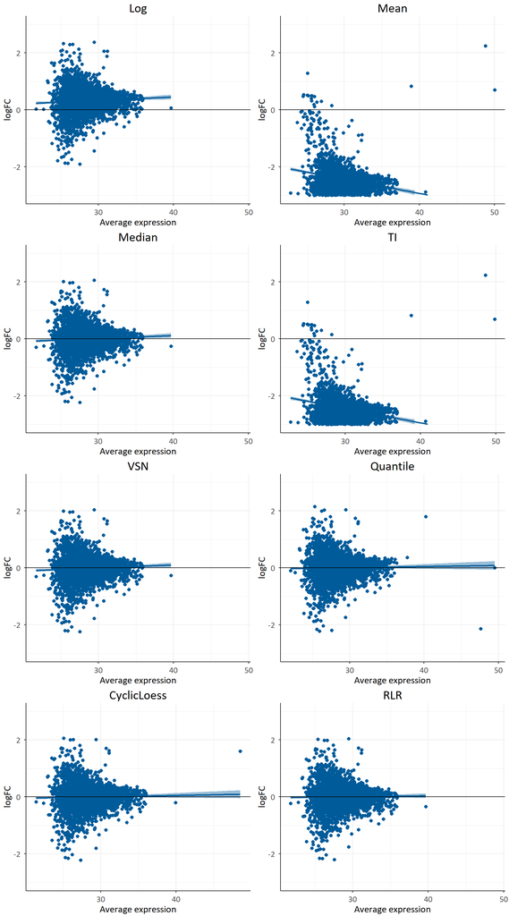

### item4

$item4

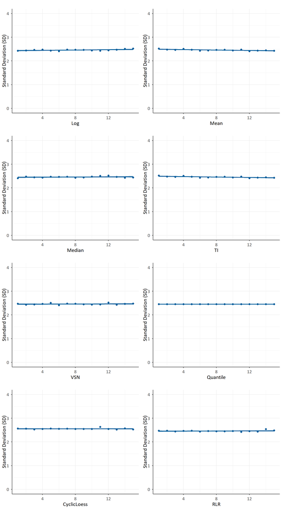

### item5

$item5

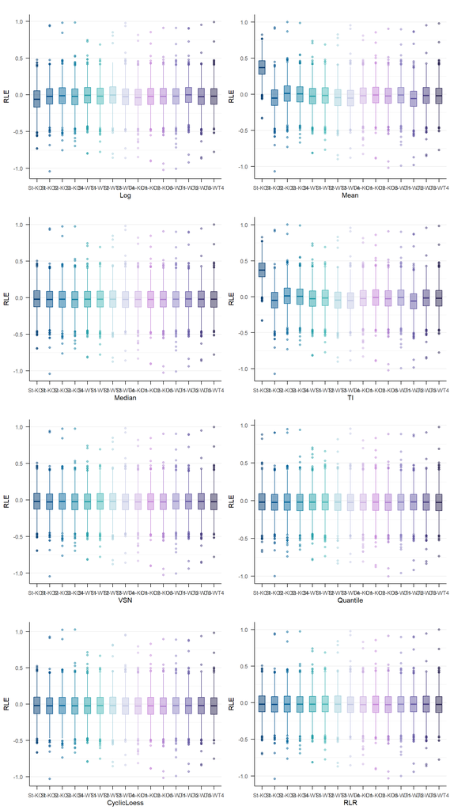

### item6

$item6

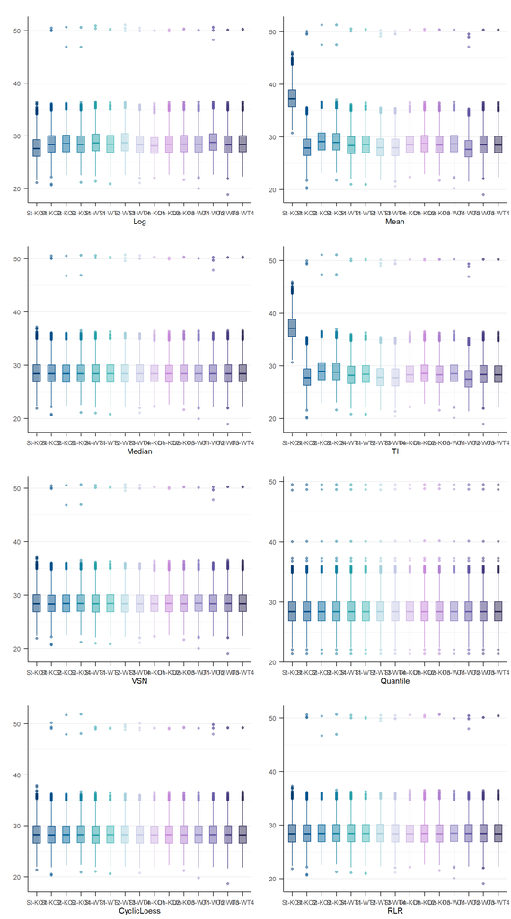

## PXD064630

### item0

$item0

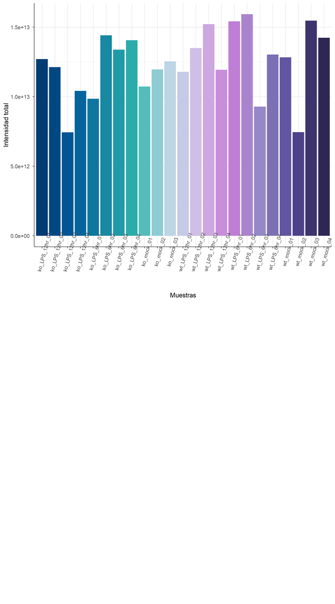

### item1

$item1

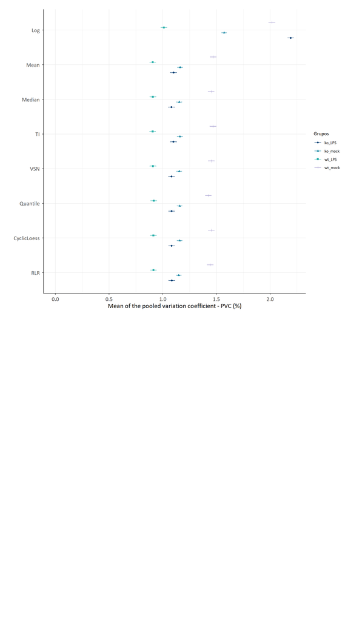

### item2

$item2

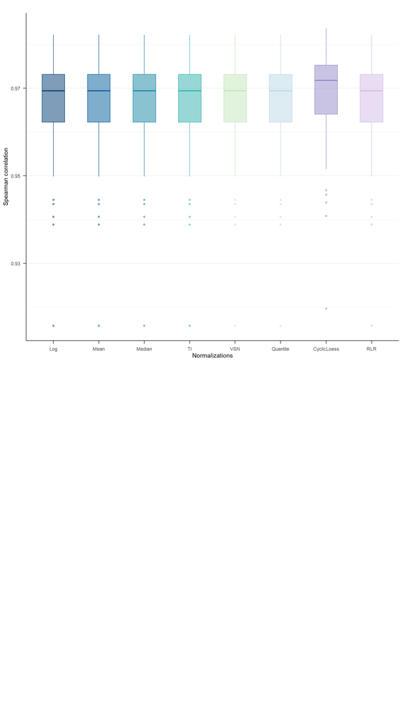

### item3

$item3

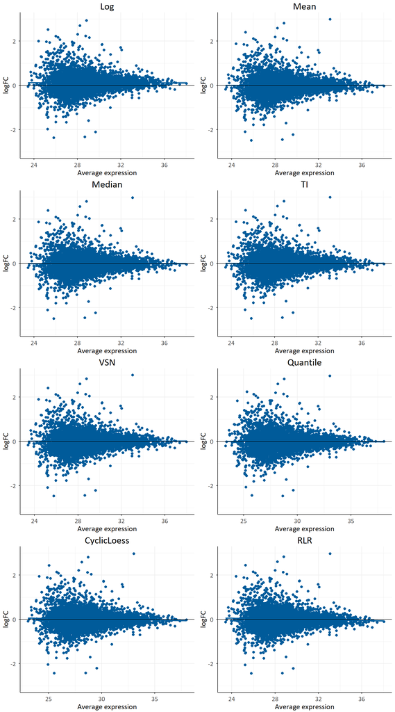

### item4

$item4

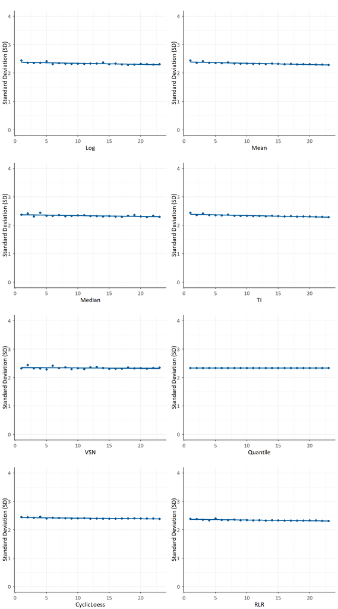

### item5

$item5

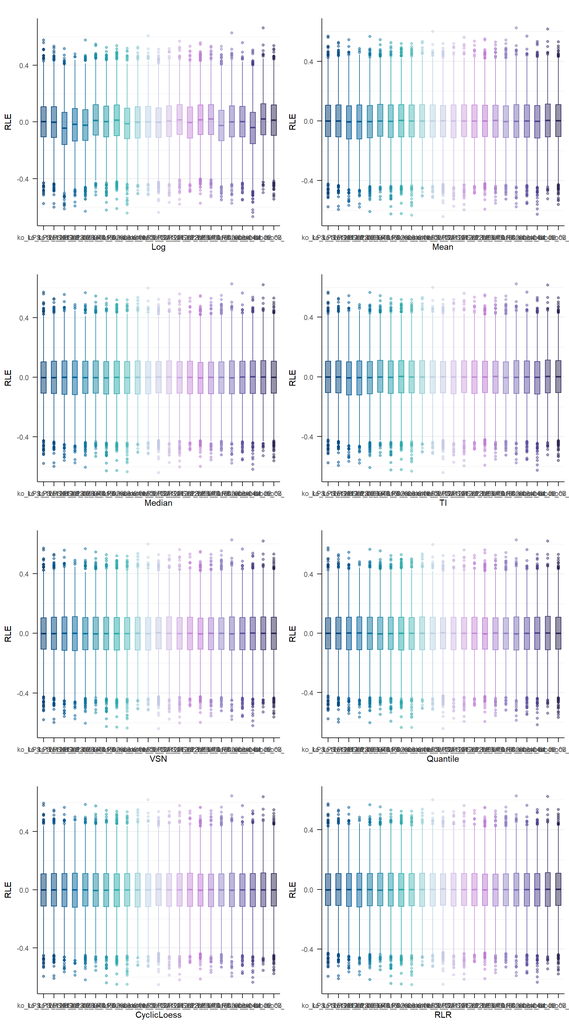

### item6

$item6

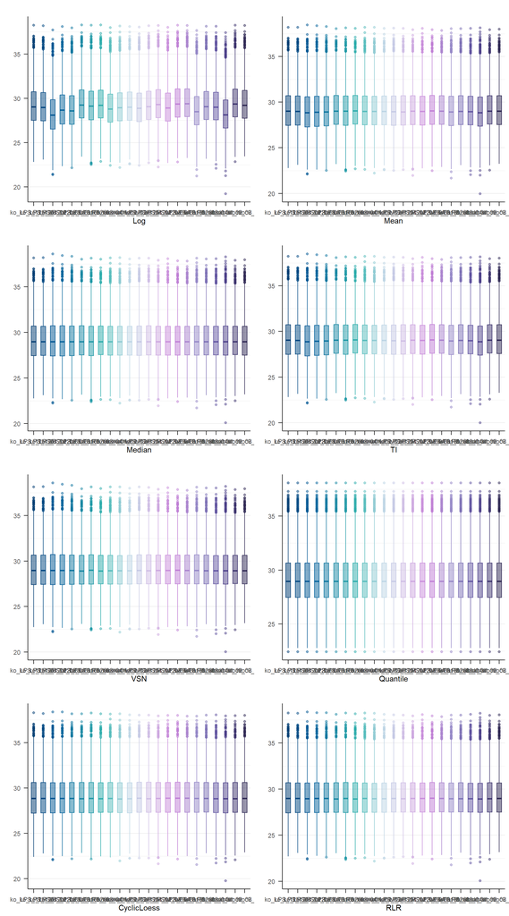

## PXD065898

### item0

$item0

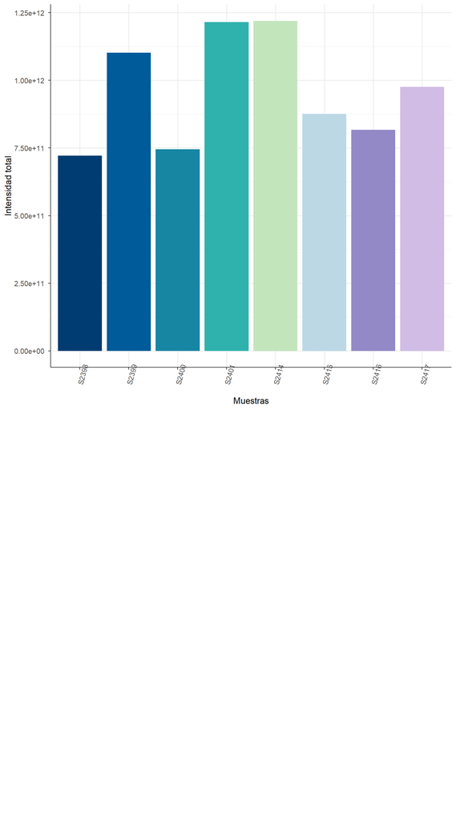

### item1

$item1

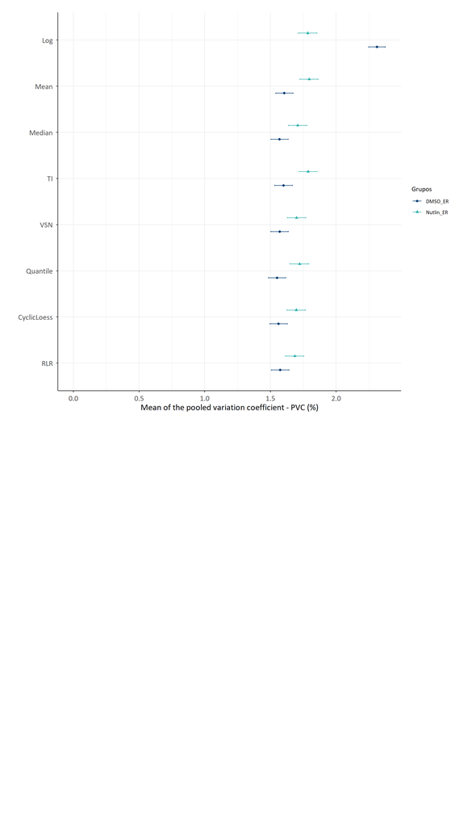

### item2

$item2

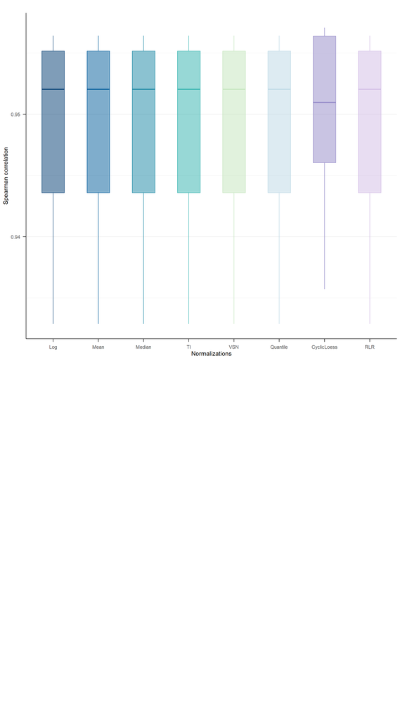

### item3

$item3

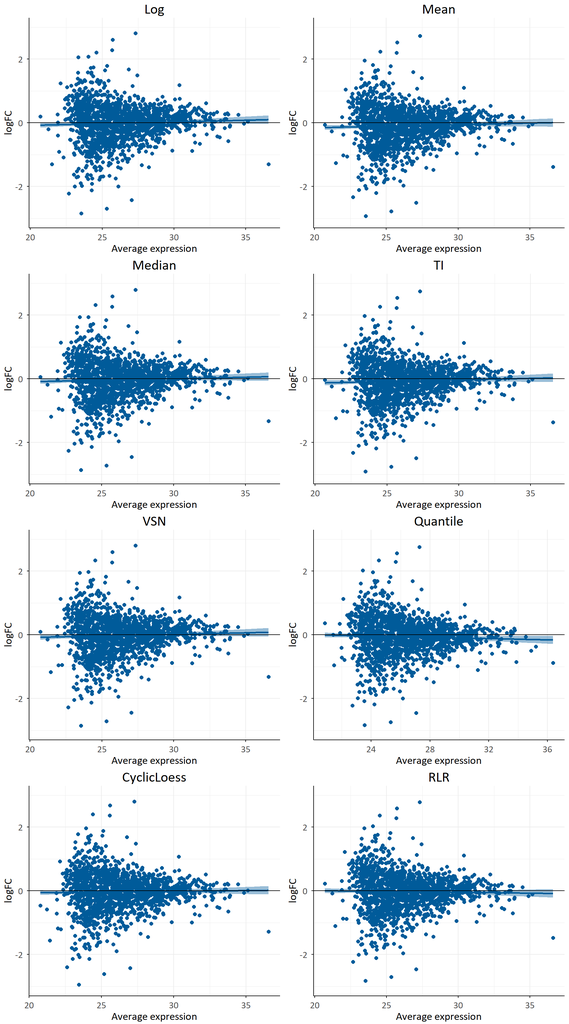

### item4

$item4

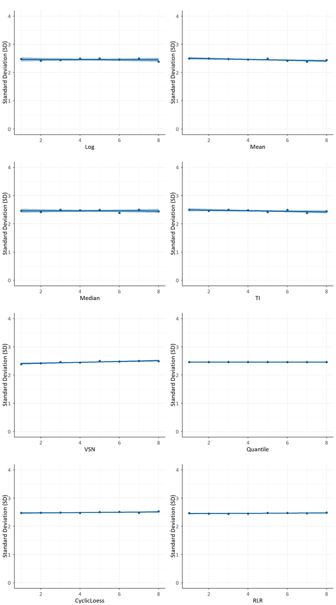

### item5

$item5

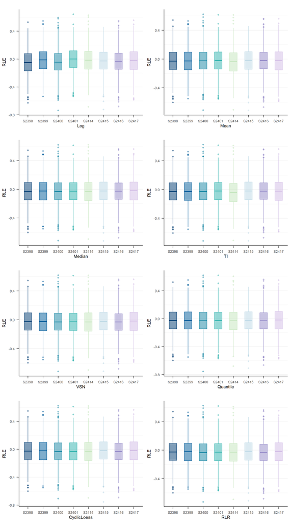

### item6

$item6

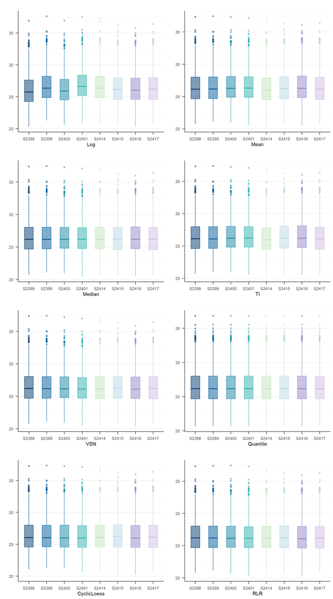

## PXD066495

### item0

$item0

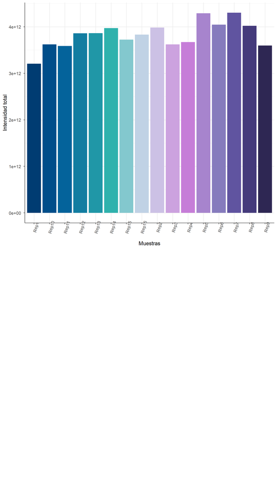

### item1

$item1

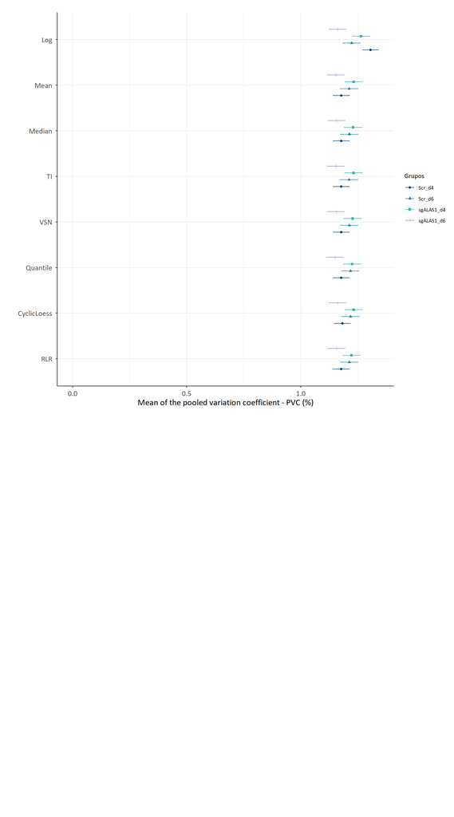

### item2

$item2

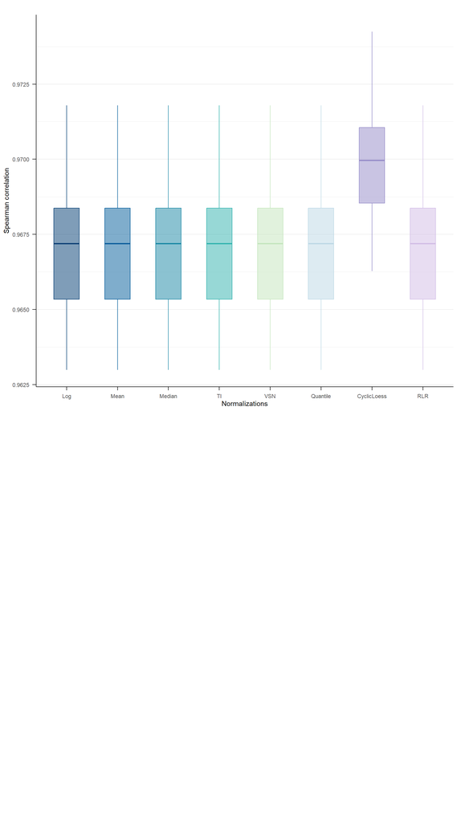

### item3

$item3

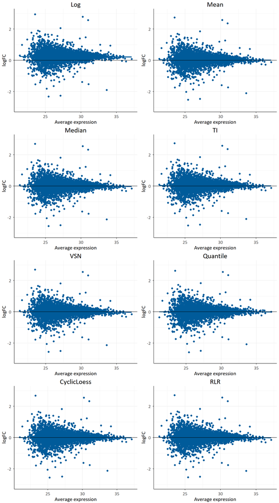

### item4

$item4

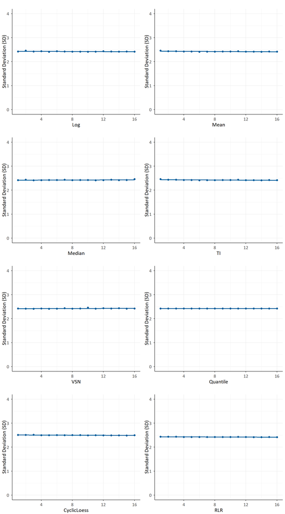

### item5

$item5

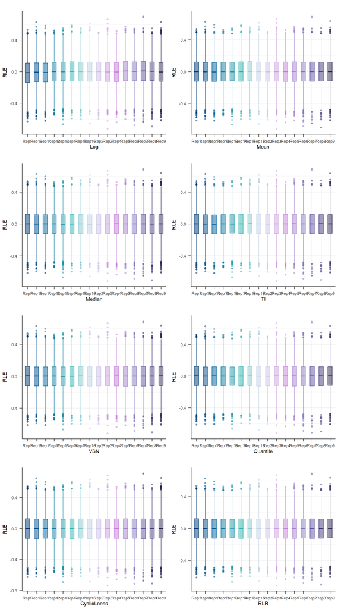

### item6

$item6

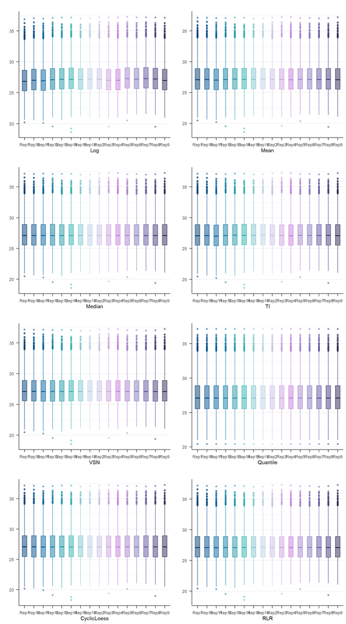

Julia García Currás

Biostatech. Advice, Training & Innovation in Biostatistics S.L. | CITIC. Universidade da Coruña (UDC)